# ANOVA IV: Interactions & simple Effects

Tehran Davis

11/6/2017

This short vignette is a continuation of last weeks focus on Factorial ANOVA [link](https://tehjespah.github.io/teaching/PSYC7014/Vignettes/Factorial_ANOVA/). Here we’re asking the question “what to do if you have an interaction”. As we discussed last week, when running a factorial ANOVA, your first question should be “do I have an interaction”. If you do have an interaction then you need to examine that interaction in detail. How do we do this? Well, let’s think about what that interaction means. As an example, let’s pull up some of the data that we looked at in lecture:

# descriptive stats and plot

```r
psych::describeBy(dataset_long$Score,group = dataset_long$Presentation)
```

```
##
##  Descriptive statistics by group
## group: Computer
##    vars  n  mean   sd median trimmed  mad min max range skew kurtosis   se
## X1    1 18 41.33 6.25   41.5   41.12 8.15  33  53    20 0.29    -1.24 1.47
## --------------------------------------------------------
## group: Standard
##    vars  n  mean    sd median trimmed   mad min max range skew kurtosis
## X1    1 18 25.67 13.11     24    25.5 14.08   6  48    42 0.26    -1.33
##      se
## X1 3.09
```

```r
psych::describeBy(dataset_long$Score,group = dataset_long$Lecture)
```

```
##
##  Descriptive statistics by group
## group: History
##    vars  n mean   sd median trimmed  mad min max range  skew kurtosis   se
## X1    1 12 34.5 8.39   35.5    34.8 8.15  20  46    26 -0.37    -1.13 2.42
## --------------------------------------------------------
## group: Physical
##    vars  n mean   sd median trimmed   mad min max range  skew kurtosis
## X1    1 12   40 10.8     43    40.9 11.86  18  53    35 -0.56       -1
##      se
## X1 3.12
## --------------------------------------------------------
## group: Social
##    vars  n mean   sd median trimmed   mad min max range skew kurtosis   se
## X1    1 12   26 15.2   24.5    25.9 20.76   6  47    41 0.04    -1.91 4.39
```

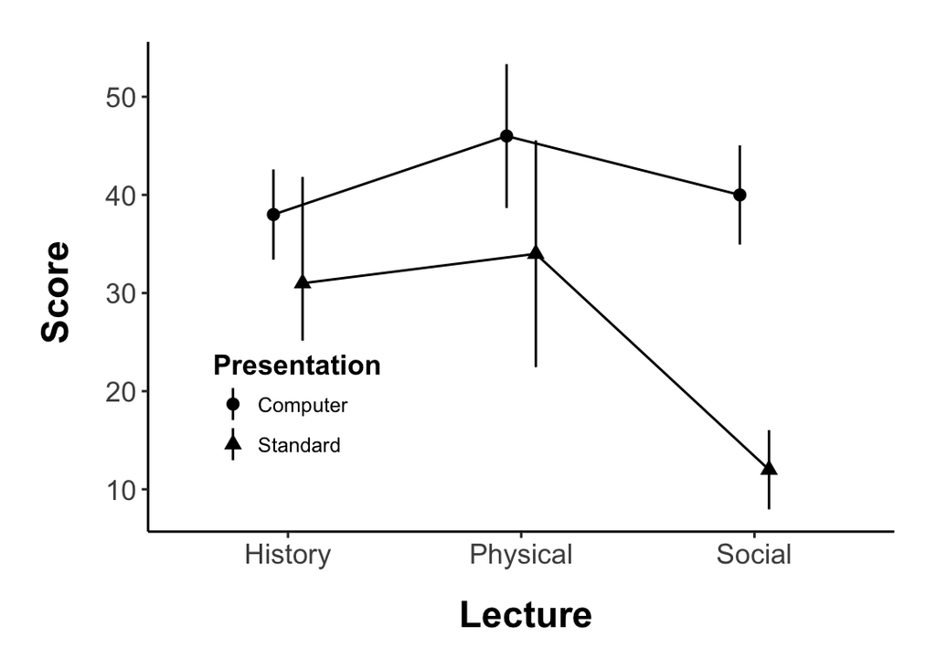

```r
require(ggplot2)
ggplot(dataset_long,mapping = aes(x = Lecture,y = Score, group=Presentation)) +
  stat_summary(geom = "pointrange",fun.data = "mean_cl_normal",position = position_dodge(.25),aes(shape=Presentation)) +
  stat_summary(geom = "line", fun.y="mean", position = position_dodge(.25)) +
  theme_classic() + theme(
    axis.title = element_text(size = 16, face = "bold", lineheight = .55),
    axis.text = element_text(size = 12),
    legend.title = element_text(size = 12, face = "bold"),
    legend.position = c(.2,.25)) +
  xlab("\n Lecture") +
  ylab ("Score \n") +
  theme(plot.margin=unit(c(.25,.25,.25,.25),"in"))
```

** note errorbars are 95% CI

# using afex::ez

```r
require(afex)

# need to make a subject column:
dataset_long$subID <- 1:nrow(dataset_long)

omnibus.aov <- afex::aov_ez(id = "subID", dv = "Score", data = dataset_long,between = c("Lecture","Presentation"),within = NULL,type = 3, return = "afex_aov", anova_table=list(es = "pes", sig_symbols = rep("", 4)))

summary(omnibus.aov)
```

```
## Anova Table (Type 3 tests)
##
## Response: Score
##                      num Df den Df  MSE       F     pes    Pr(>F)
## Lecture                   2     30 55.6 10.7374 0.41719  0.000304 ***
## Presentation              1     30 55.6 39.7302 0.56977 5.993e-07 ***
## Lecture:Presentation      2     30 55.6  6.4928 0.30209  0.004539 **
## ---
## Signif. codes:  0 '***' 0.001 '**' 0.01 '*' 0.05 '.' 0.1 ' ' 1
```

Our ANOVA reveals two main effects and in interaction. Looking at the plot (always, always plot before you think about doing any sort of follow-ups!!) it is fairly apparent what is happening—the moving from one lecture to the next, we see a much more dramatic decrease in score for the Social group in the **Standard** presentation group compared to the **Computer** presentation. That is, moving from left to right the pattern of change is different for the **Standard** group, compared to the **Computer** group. This is what our eyeball test is telling us—we need to confirm it with some stats! There are two ways to address this interaction, each involves sub-setting the data for further analysis.

When you have an interaction, you proceed by testing for differences between means for one condition, on **each individual level of the other**. For example, we can test for and effect of Lecture Type when the Presentation is Computer, and effect of Lecture Type when the Presentation is Standard. In this case you would run two separate simple effects ANOVAs, each taking a look at changes for each line in the plot above.

–OR–

You could check for difference between Presentations on each Lecture type. Here you would be comparing Computer v Standard in each of the Lecture conditions. This would involve running three ANOVAs each checking for the Presentation differences (circle v. triangle) present at History, Physical, and Social.

Which you choose, ultimate depends on which narrative you are trying to convey in your data. Here it may make sense to do the former. That is eyeballing the data it looks like the means in the Computer presentation level are not as different from one another as the Standard presentation.

# Running the simple effects ANOVA in 6 steps:

Running a follow-up simple effects ANOVA is akin to running a One-way ANOVA with one important caveat. When you run the follow-up ANOVA you need to use the error terms from your omnibus ANOVA. That is your simple effects ANOVA calls for the omnibus ANOVA errors: Sum of Squares, Mean Square Error, and denominator degrees of freedom. What this means is that the F-value (and subsequent p-values) that you get in you initial follow-up ANOVA is **WRONG**.

There are several steps that need to be run for each simple effects ANOVA:

## step 1: get the omnibus ANOVA:

Assuming you haven’t already we need to run the omnibus ANOVA. Here I’m running all ANOVAs using `afex::aov_ez` and saving them as `afex_aov` objects. This will be useful to me later on when extracting info for my correction calculations:

```r
require(afex)

# need to make a subject column for afex:
dataset_long$subID <- 1:nrow(dataset_long)

# run omnibus:
omnibus.aov <- afex::aov_ez(id = "subID", dv = "Score", data = dataset_long,between = c("Lecture","Presentation"),within = NULL,type = 3, return = "afex_aov", anova_table=list(es = "pes", sig_symbols = rep("", 4)))

summary(omnibus.aov)
```

```
## Anova Table (Type 3 tests)
##
## Response: Score
##                      num Df den Df  MSE       F     pes    Pr(>F)
## Lecture                   2     30 55.6 10.7374 0.41719  0.000304 ***
## Presentation              1     30 55.6 39.7302 0.56977 5.993e-07 ***
## Lecture:Presentation      2     30 55.6  6.4928 0.30209  0.004539 **
## ---
## Signif. codes:  0 '***' 0.001 '**' 0.01 '*' 0.05 '.' 0.1 ' ' 1
```

## step 2: get the MSError, Error df, and Error SS from omnibus ANOVA

In `R`, we can do this by using some of the `attribues()` of the `omnibus.aov` (afex_aov object).

For example if we take a look at `omnibus.aov$anova_table` we see that we can get the `MSE` and `den Df` from its attributes (we only need one value, so I’m taking the first instance). We can calculate the omnibus Error SS by multiplying the two:

```r
omnibus_mse <- omnibus.aov$anova_table$MSE[1]
omnibus_df <- omnibus.aov$anova_table$'den Df'[1]
omnibus_ss_error <- omnibus_mse * omnibus_df
```

## step 3: subset your data accordingly

In order to do this we will need to subset the data. For example I am interested in running my follow-ups on Computer data and Standard data separately, so my first move is to perform this subset:

```r
computer.data <- subset(dataset_long, Presentation=="Computer")
standard.data <- subset(dataset_long, Presentation=="Standard")
```

## step 4: run your One-way simple effects ANOVA(s)

Here I’m focusing on the `computer.data` for my example. I’ll return to the `standard.data` later. Again, I’m testing for an effect of Lecture Type on the `computer.data`. Note that you only include `Lecture` in you `between =` call:

```r
computer.aov <- afex::aov_ez(id = "subID", dv = "Score", data = computer.data,between = "Lecture", within = NULL,type = 3,return ="afex_aov", anova_table=list(es = "pes", sig_symbols = rep("", 4)))
```

## step 5: get the treatment MS, df, SS, and F-value from your simple ANOVA

As before, this can be done by calling attributes from our simple ANOVA, `computer.aov`, and using what we know about calculating those values that can’t be extracted:

```r
simple_f <- computer.aov$anova_table$F
simple_df <- computer.aov$anova_table$`num Df`
simple_mse <- computer.aov$anova_table$MSE[1]

# we can calculate the treatment MS by:
simple_ms <- simple_mse*simple_f

# and the simple SS:
simple_ss <- simple_ms * simple_df
```

## step 6: make our corrections

As I noted above the F-value, p-value, and effect size (pes, $\eta_p^2$) that you originally obtain in `computer.aov` (you can take a look by using the `summary` function) are not correct. We need to make the appropriate corrections. This can be done my hand, using the values we’ve extracted and calculated above:

```r
# calculate F using simple treatment  MS and omnibus MSE
corrected_f <- simple_ms/omnibus_mse

# the pf function calculates the cummulative p.value using the corrected_f and appropriate degrees of freedom. Since its cumulative we subtract this result from 1:

corrected_p <- (1-pf(corrected_f,df1 = simple_df,df2 = omnibus_df))

# calculate the pes by using simple treatment SS and omnibus MSE:
corrected_pes <- (simple_ss/(simple_ss+omnibus_ss_error))
```

Congrats!! You have made the appropriate corrections! Taking a look at your corrected result it appears that we should accept the null hypothesis of no difference in means on the computer data.

# Building a function to ninja this for us

Given what we know about how we made these calculations we can create a function in `R` to simplify this process. All we need an omnibus `afex_aov` object and simple `afex_aov` object to extract from. Given that, we can set up the function by copying the hand calculations from the previous steps. Here I’m building the function `simpleEffectsAOV` to handle this for us. Feel free to use this function BUT make sure you understand what is happening in each line:

```r
simpleEffectsAOV <- function(full.aov,simple.aov){
  # get important values from full:
  full_mse <- full.aov$anova_table$MSE[1]
  full_df <- full.aov$anova_table$'den Df'[1]
  full_ss_error <- full_mse * full_df

  # get important values from simple effects aov
  simple_f <- simple.aov$anova_table$F
  simple_df <- simple.aov$anova_table$`num Df`
  simple_mse <- simple.aov$anova_table$MSE[1]
  simple_ms <- simple_mse*simple_f
  simple_ss <- simple_ms * simple_df

  # get corrected F
  corrected_f <- simple_ms/full_mse

  # get corrected P
  p.value <- (1-pf(corrected_f,df1 = simple_df,df2 = full_df))

  # round p.value to 3 digits
  p.value <- round(p.value,3)

  p.value <- ifelse(p.value>.001,paste0("p = ", p.value), "p < .001")

  # get simple effects pes:
  pes <- (simple_ss/(simple_ss+full_ss_error))

  ftest <- paste0("F(",simple_df, ",", full_df,") = ", round(corrected_f,digits = 3), ", ", p.value, ", pes=", round(pes,3))

  # round our obtained full_mse to 3 digits:
  full_mse <- round(full_mse,digits = 3)
  output <- cbind(row.names(simple.aov[[1]]),full_mse,ftest)
  dimnames(output)[[2]][1] <- "Effect"
  show(output)
  }
```

Note that a copy of this function is available on my github cite to download and can be sourced by you using the following:

```r
source("https://raw.githubusercontent.com/tehjespah/tehjespah.github.io/master/Rscripts/simpleEffectsAOV.R")
```

And now I can use this function like so:

```r
simpleEffectsAOV(full.aov = omnibus.aov, simple.aov = computer.aov)
```

```
##      Effect    full_mse ftest
## [1,] "Lecture" "55.6"   "F(2,30) = 1.871, p = 0.172, pes=0.111"
```

And now quickly let’s run the **Standard** data:

```r
standard.aov <- afex::aov_ez(id = "subID", dv = "Score", data = standard.data,between = "Lecture", within = NULL,type = 3,return ="afex_aov", anova_table=list(es = "pes", sig_symbols = rep("", 4)))

simpleEffectsAOV(full.aov = omnibus.aov, simple.aov = standard.aov)
```

```
##      Effect    full_mse ftest
## [1,] "Lecture" "55.6"   "F(2,30) = 15.36, p < .001, pes=0.506"
```

# Interpreting these results:

So it looks like we have no Lecture type effect on our computer data, but we do have one on our standard data. Given our results, we need to run further tests on our `standard.data` results to tease out the differences between lecture types. Here we can call on our old friend Tukey HSD, but again with the same caveat. Our calculations (in this case of the critical `q` (see Howell text) must include the error terms from the omnibus ANOVA. In order to do so we can still use the `agricolae::HSD.test` function, but where before we simply used the `aov` object as one of our arguments, no we need to enter our appropriate `MSE` and `df` by hand. Here is a comparison of the wrong way and the right way to perform this follow-up. Note the differences in the `Critical Value of Studentized Range` for each output:

```r
### THIS IS WRONG !!!!! ###
agricolae::HSD.test(standard.aov$aov,trt = "Lecture", console = T, group = F)
```

```
##
## Study: standard.aov$aov ~ "Lecture"
##
## HSD Test for Score
##
## Mean Square Error:  80.8
##
## Lecture,  means
##
##          Score       std r Min Max
## History     31 10.315038 6  20  46
## Physical    34 11.009087 6  18  48
## Social      12  3.847077 6   6  16
##
## Alpha: 0.05 ; DF Error: 15
## Critical Value of Studentized Range: 3.673378
##
## Comparison between treatments means
##
##                    difference pvalue signif.        LCL      UCL
## History - Physical         -3 0.8337         -16.480178 10.48018
## History - Social           19 0.0062      **   5.519822 32.48018
## Physical - Social          22 0.0019      **   8.519822 35.48018
```

```r
### THIS IS RIGHT !!!! ####
agricolae::HSD.test(standard.data$Score,trt = standard.data$Lecture,DFerror = 30,MSerror = 55.6,alpha = .05,console = T, group = F)
```

```
##
## Study: standard.data$Score ~ standard.data$Lecture
##
## HSD Test for standard.data$Score
##
## Mean Square Error:  55.6
##
## standard.data$Lecture,  means
##
##          standard.data.Score       std r Min Max
## History                   31 10.315038 6  20  46
## Physical                  34 11.009087 6  18  48
## Social                    12  3.847077 6   6  16
##
## Alpha: 0.05 ; DF Error: 30
## Critical Value of Studentized Range: 3.48642
##
## Comparison between treatments means
##
##                    difference pvalue signif.        LCL       UCL
## History - Physical         -3 0.7671         -13.613081  7.613081
## History - Social           19 0.0003     ***   8.386919 29.613081
## Physical - Social          22 0.0000     ***  11.386919 32.613081
```

Given our latter result above we see that in the Standard presentation, scores based on Social lectures were significantly less than the other two.

# Example write-up:

> To test for the effects of Presentation style (Standard, Computer) and Lecture Type (Physics, History, Social) we ran a 2 × 3 factorial ANOVA. This ANOVA revealed main effects for both Presentation style, $F(1,30)=39.73, p<.001, \eta_p^2=.57$, and Lecture type, $F(2,30)=10.74, p<.001, \eta_p^2=.42$.

> As shown in Figure 1, these effects we qualified by a Presentation style × Lecture type interaction, $F(2,30)=6.49, p=.005, \eta_p^2=.30$. Differences in Lecture type were only observed when material was presented in the Standard presentation, $F(2,30)=15.36, p<.001, \eta_p^2=.51$, where scores from the Social lecture were significantly different from the remaining two (Tukey HSD, *p*< .05). No differeces were observed when the material was presented via computer (*p*>.05). Overall, participant perdormed better when the material was presented via computer (*M±SD*: 41.33 ± 6.25) compared to standard presentations (25.67 ± 13.11).

# Performing this in SPSS (video)

[interactive chart not shown]